# Transpose_K-means_PAM

- From the previous run in the previous file called ‘K-means_PAM.Rmd’ where the data were not transposed to have bacteria as observation rows, the Dim1 was 2.4% and the Dim 2 was 2%

- Maybe I should also do PCA again based on transposed rows for bacteria?
- But first, is a nother run of PAM going to give similar or same results and be stable?

```r
library(cluster)
pam(x = scale(t_rev_bac_prop), # scale and standardize
    k = 239, # 239 explains at least 80 % from PCA
    diss = F, #F = x is df of observations not dissim matrix
    metric = "euclidean", # not manhattan
    # may ocnsider changing to L1 norm if PAM with euclidean doesn't work out
    #medoids = if(is.numeric(nstart)) "random",
    #nstart = if(variant == "faster") 1 else NA,
    stand = TRUE, # F = x is not standardized
   # cluster.only = T,
    do.swap = TRUE, # T = yes, do swap phase of algorithm
    # keep.diss = !diss && !cluster.only && n < 100,
    # keep.data = !diss && !cluster.only,
    variant = "faster" ,# c("original", "o_1", "o_2", "f_3", "f_4", "f_5", "faster"),
   # pamonce = FALSE,
    trace.lev = 0) -> t_pam_out_2
```

```r
# first run
t_pam_out$silinfo$avg.width
```

```
## [1] 0.4131596
```

```r
# second run - the average width is going up
# but there are some ave widths with negative values
# which from documentation means they are probably classified wrong
t_pam_out_2$silinfo$avg.width
```

```
## [1] 0.4704188
```

```
##     cluster size ave.sil.width
## 1         1    1          0.00
## 2         2    1          0.00
## 3         3    1          0.00
## 4         4    1          0.00
## 5         5    1          0.00
## 6         6    1          0.00
## 7         7    1          0.00
## 8         8    1          0.00
## 9         9    1          0.00
## 10       10    1          0.00
## 11       11    1          0.00
## 12       12    1          0.00
## 13       13    1          0.00
## 14       14    1          0.00
```

[output cut: 225 more lines]

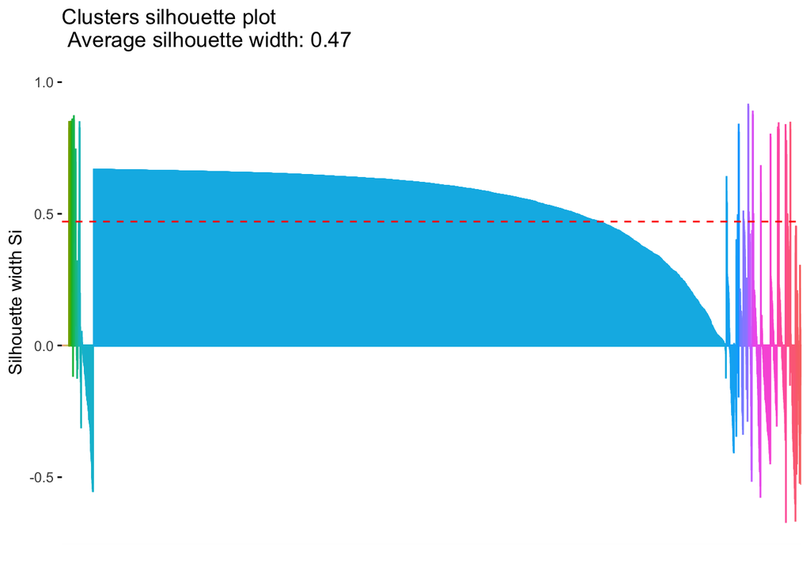

```r
fviz_silhouette(t_pam_out_2,
                legend = "none")
```

### Run PAM with 20 clusters to see if it simplifies

```r
pam(x = scale(t_rev_bac_prop), # scale and standardize
    k = 20, # 239 explains at least 80 % from PCA
    diss = F, #F = x is df of observations not dissim matrix
    metric = "euclidean", # not manhattan
    # may ocnsider changing to L1 norm if PAM with euclidean doesn't work out
    #medoids = if(is.numeric(nstart)) "random",
    #nstart = if(variant == "faster") 1 else NA,
    stand = TRUE, # F = x is not standardized
   # cluster.only = T,
    do.swap = TRUE, # T = yes, do swap phase of algorithm
    # keep.diss = !diss && !cluster.only && n < 100,
    # keep.data = !diss && !cluster.only,
    variant = "faster" ,# c("original", "o_1", "o_2", "f_3", "f_4", "f_5", "faster"),
   # pamonce = FALSE,
    trace.lev = 0) -> t_pam_out_20
```

```r
t_pam_out_20$silinfo$avg.width
```

```
## [1] 0.9670806
```

- Wow, this is much better than before
- Can the NBClust find better?

```r
library(NbClust)
fviz_nbclust(x = scale(t_rev_bac_prop),
             FUNcluster = pam,
             method = "silhouette"
             ) -> nbclust_pam_out
```

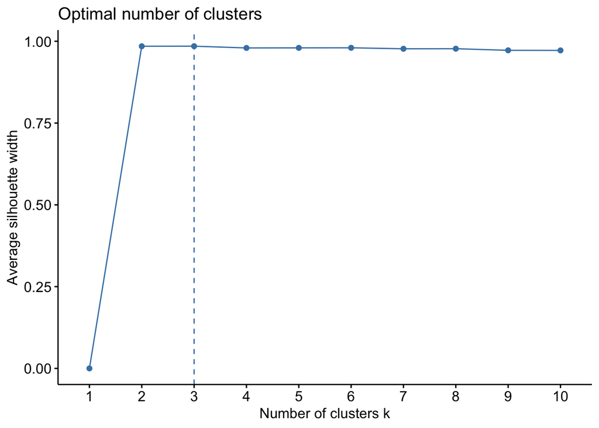

```r
nbclust_pam_out
```